# Climate Change Slideshow

## What is Climate Change?

Climate change has become a bigger concern in recent years as its effects become harder to ignore and research continues to reveal just how much it’s impacting our world. In the U.S., we’ve seen more frequent and intense natural disasters, like wildfires and hurricanes, directly caused by these changes. The biggest factor behind this shift is carbon dioxide (Co2) emissions, which come from sources like power plants, cars, and factories.

## Past Co2 Levels

This graph shows the natural cycles of Co2 in the atmosphere without human emissions producing Co2. The Co2, which is measured in parts per million (ppM), and measures how much Co2 there is in the atmosphere. These measurements, dating back 800000 years, were collected by drilling into ancient ice and measuring the concentration of Co2 found trapped in air pockets. The cycles that can be seen are due to the cooling and warming cycles where as Co2 builds up in the atmosphere it blocks some of the sun’s radiation allowing the planet to cool and ice to form. This is followed by a drop in Co2 as the gas is trapped in the ice and in plants that can now grow on the warmer planet. However, as can be seen in the far right of the graph, this natural cycle has been disrupted by human activities causing the Co2 levels to skyrocket to never before seen levels.

## Industrial Revolution

Taking a closer look at more recent Co2 levels, we can see the start of the industrial revolution marked by an uptick in Co2 as humans begin to burn coal. This is followed by an exponential increase in emissions as humans have scaled up our production and have begun to burn oil and other fossil fuels. This activity has led to what we now call climate change.

## Recent Emmsions

Despite our many efforts to slow emissions in recent years, atmospheric Co2 levels have continued to rise steadily. This increase has led to significant environmental challenges, with one of the most pressing being global warming. Historically, CO₂ played a role in reflecting the sun’s rays during ice ages, but today, it acts as a heat-trapping gas through the greenhouse effect. This warming has triggered severe consequences, including melting glaciers, rising sea levels, and further temperature increases.

Looking at historical Co2 data, there is a clear pattern of seasonal cycles. When we zoom in, these patterns become even clearer. These changes occur due to plant activity during spring and summer, plants absorb Co2, leading to a noticeable drop in atmospheric levels. However, in winter, Co2 is released back into the air, causing a sharp increase. These cycles are measured in the Northern Hemisphere, but a similar pattern is observed in the Southern Hemisphere, just reversed and with slightly less intensity.

## The Future of Co2

If humanity continues emitting Co2 at the current rate, these patterns will persist, only increasing environmental problems and risks for future generations.

## What You Can Do to Help

Everyone can play a role in reducing emissions and contributing to a more sustainable future. There are countless initiatives worldwide aimed at combating climate change. Getting involved in local volunteer efforts, supporting policies that promote sustainability, and making eco-friendly choices in daily life are all impactful ways to help reduce emissions and protect our planet.

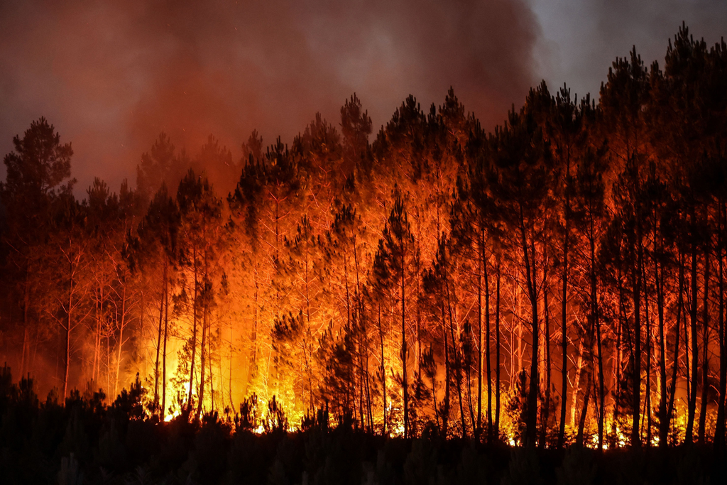

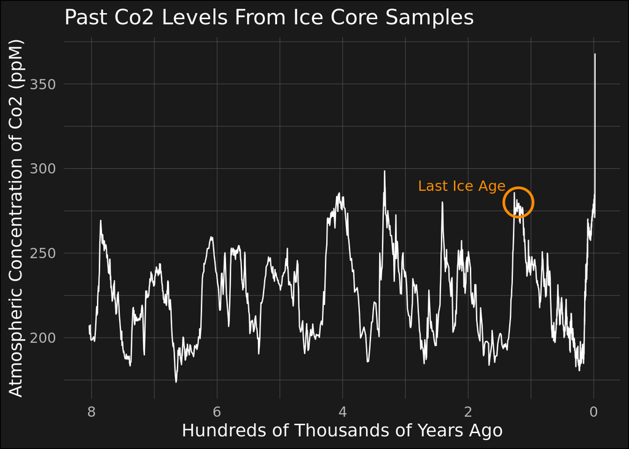

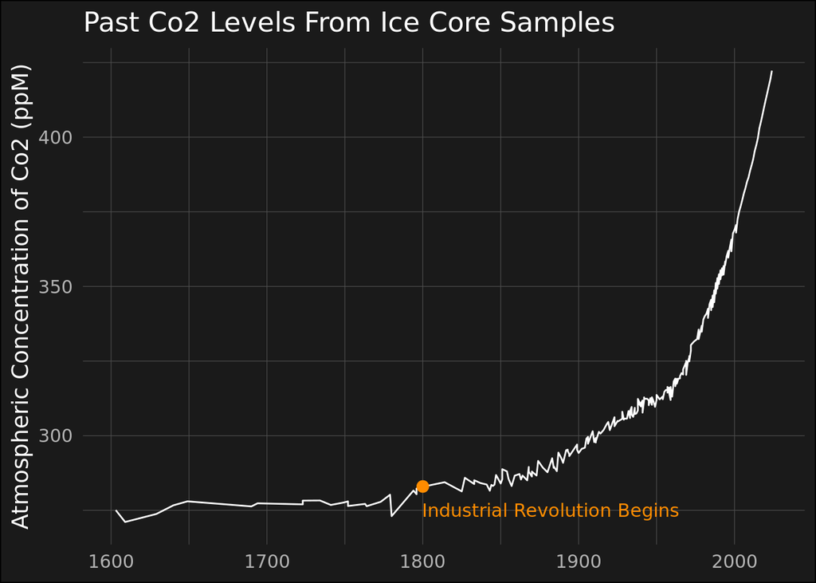

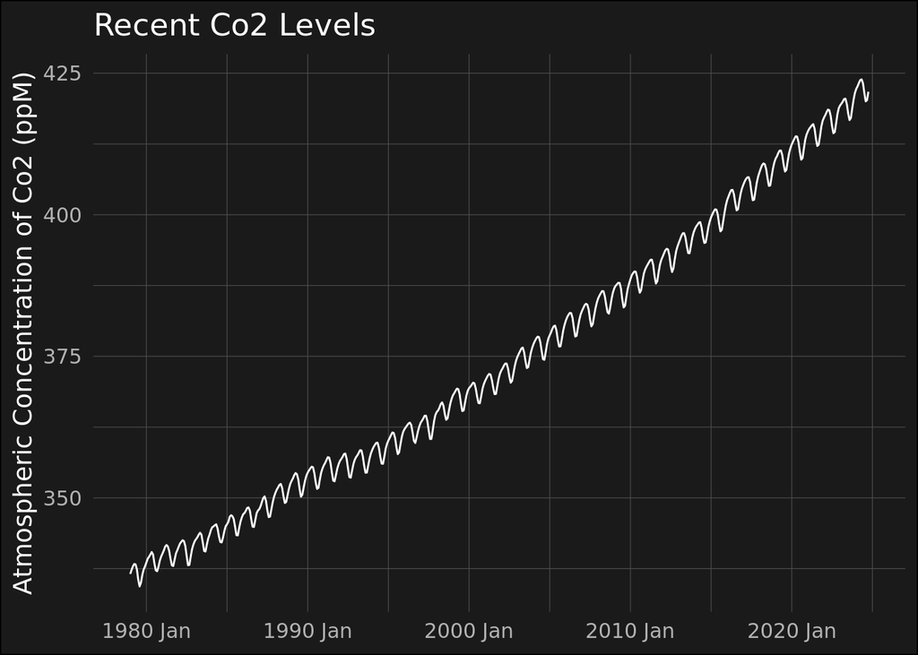

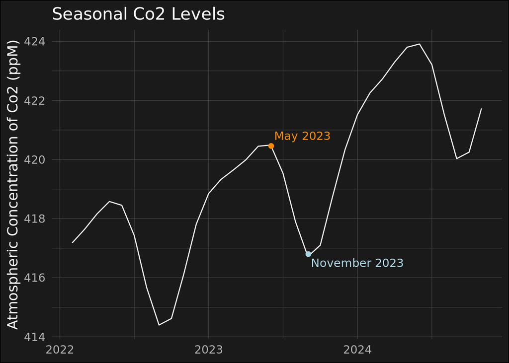

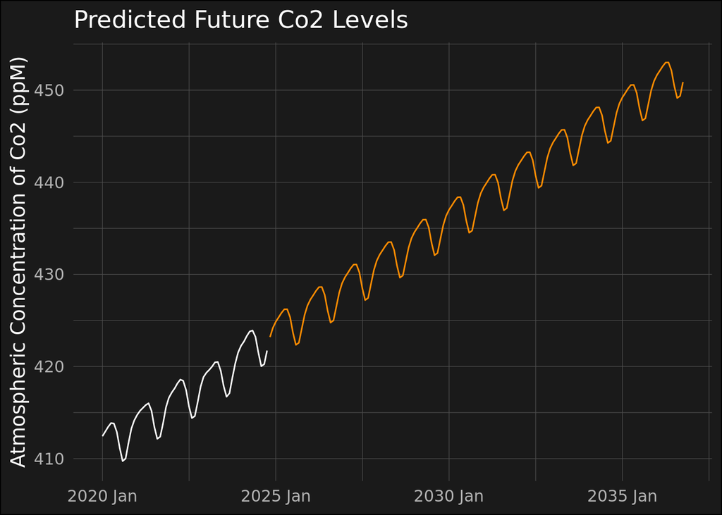

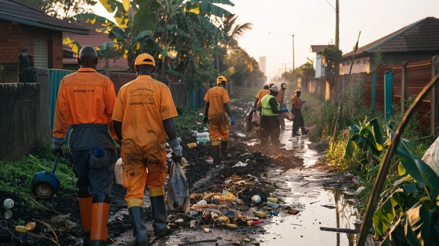

# Sources

- Lan, X., Tans, P. and K.W. Thoning: Trends in globally-averaged CO2 determined from NOAA Global Monitoring Laboratory measurements. Version Monday, 06-Jan-2025 10:06:16 MST https://doi.org/10.15138/9N0H-ZH07
- Bereiter, B., S. Eggleston, J. Schmitt, C. Nehrbass-Ahles, T. F. Stocker, H. Fischer, S. Kipfstuhl, J. Chappellaz. 2015. Revision of the EPICA Dome C CO2 record from 800 to 600 kyr before present. Geophysical Research Letters, 42(2), 542-549. doi: 10.1002/2014GL061957
- Lindsey, Rebecca. “Climate Change: Atmospheric Carbon Dioxide.” NOAA Climate.Gov, NOAA, 9 Apr. 2024, www.climate.gov/news-features/understanding-climate/climate-change-atmospheric-carbon-dioxide.